# Week 3

Jiantong Wang

# Basic Tools For Forecasting

## Seasonal plots

```r
miles <- read.csv("Revenue_miles_2.csv")
str(miles)
```

```
## 'data.frame':    192 obs. of  3 variables:
##  $ DATE            : chr  "2000-01-01" "2000-02-01" "2000-03-01" "2000-04-01" ...
##  $ Miles.Thousands.: int  49843099 49931931 61478163 58981617 61223861 65601574 67898320 67028338 56441629 58834210 ...
##  $ Miles..Billions.: num  4.98 4.99 6.15 5.9 6.12 ...
```

```r
library(forecast)
```

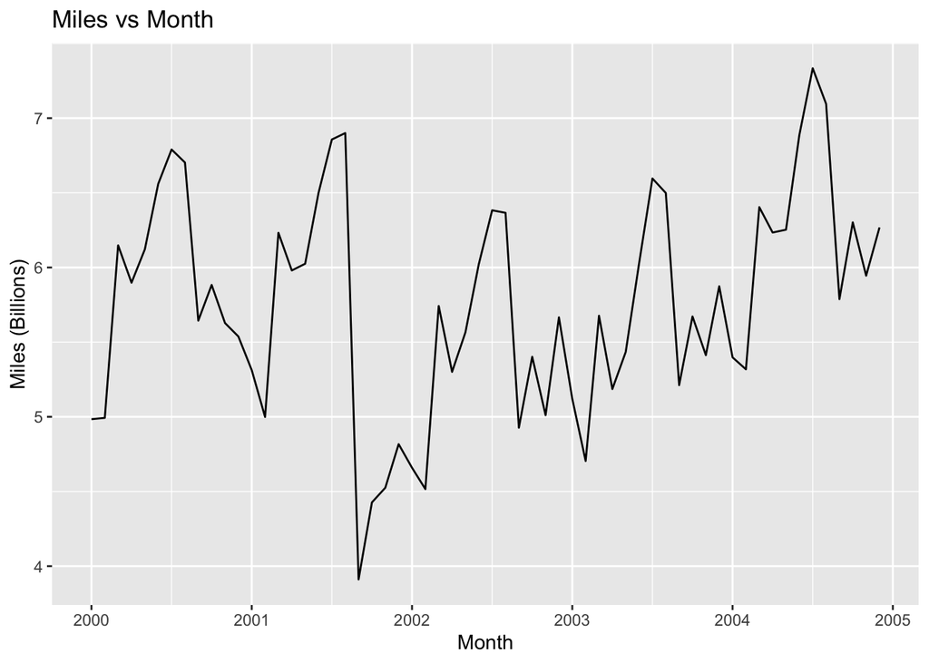

```r
miles.ts <- ts(miles$Miles..Billions.,start = c(2000,1),end = c(2004,12),frequency = 12)
autoplot(miles.ts,xlab = "Month", ylab = "Miles (Billions)", main = "Miles vs Month")
```

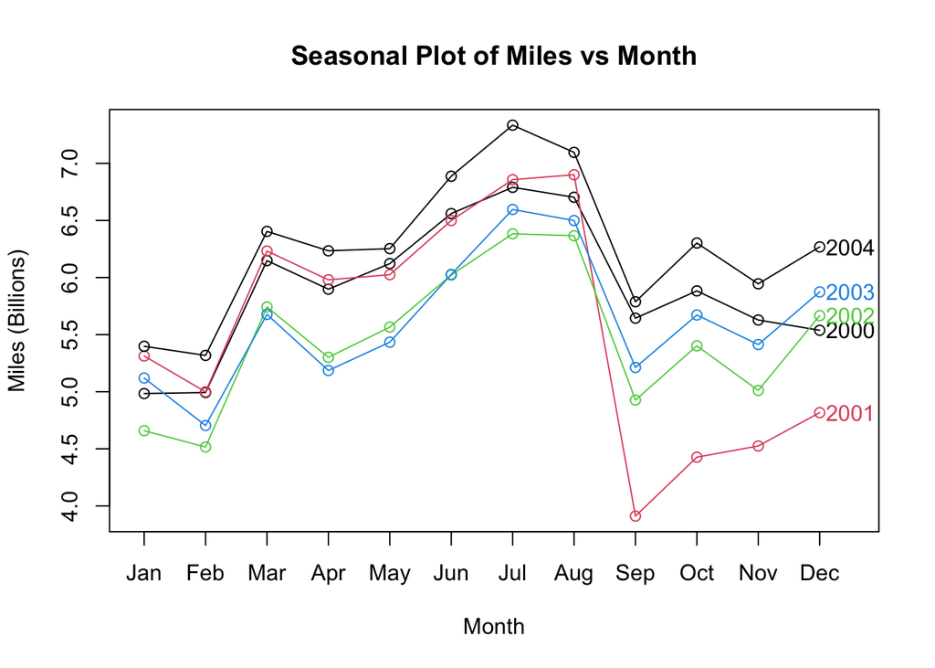

```r
seasonplot(miles.ts,xlab = "Month", ylab = "Miles (Billions)", main = "Seasonal Plot of Miles vs Month",year.labels = T,col = 1:4)
```

## Transformations

#### Summary of Dulles Data

```r
Dulles <- read.csv("Dulles_2.csv", header = T)
summary(Dulles)
```

```
##       Year      Passengers..000s.
##  Min.   :1963   Min.   :  641
##  1st Qu.:1976   1st Qu.: 2083
##  Median :1989   Median : 8947
##  Mean   :1989   Mean   : 8456
##  3rd Qu.:2002   3rd Qu.:14393
##  Max.   :2015   Max.   :22129
```

```r
library(zoo)
```

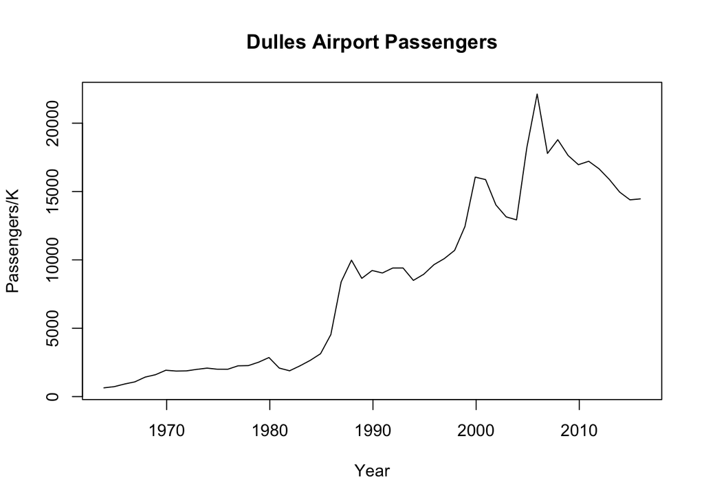

```r
Dulles.plot <- ts(data = Dulles$Passengers..000s., start = as.yearmon("1963-12"), frequency = 1)
plot(Dulles.plot, xlab = "Year", ylab = "Passengers/K",main = "Dulles Airport Passengers")
```

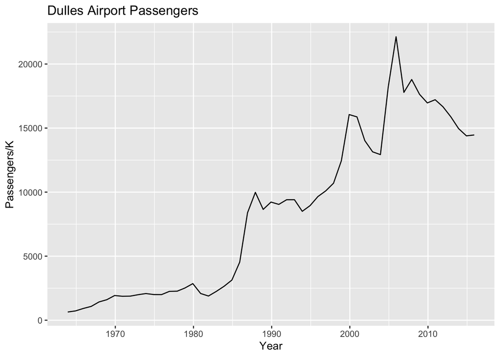

```r
autoplot(Dulles.plot, xlab = "Year", ylab = "Passengers/K",main = "Dulles Airport Passengers")
```

### -Differences

A simple way to view a single (or “first order”) difference is to see it as
$$Y_t−Y_{t−k}$$
Time Series Plot for the First Differences of the Dulles Passenger Series.

#### -“diff()” function

##### -Arguments

**x:**  
**a numeric vector or matrix containing the values to be differenced.**

**lag:**  
**an integer indicating which lag to use.**

**differences**  
**an integer indicating the order of the difference.(We won’t use this argument much)**

```r
x <-  c(3,2,4,6,7,3,1,8)
x
```

```
## [1] 3 2 4 6 7 3 1 8
```

```r
diff(x, lag = 1)
```

```
## [1] -1  2  2  1 -4 -2  7
```

```r
diff(x, lag = 2)
```

```
## [1]  1  4  3 -3 -6  5
```

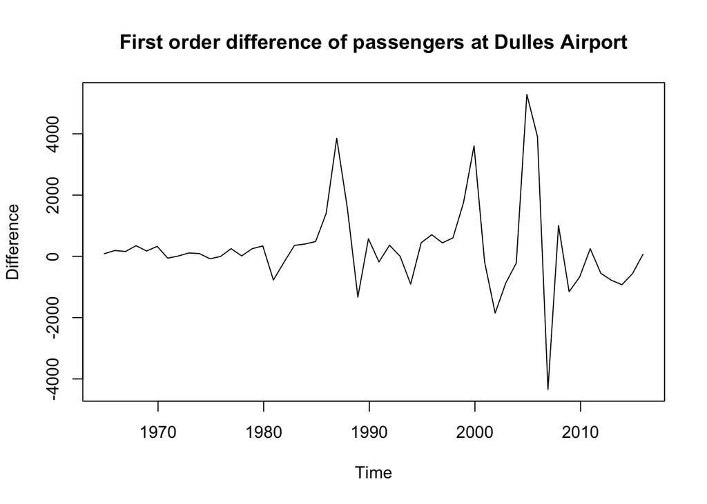

```r
Diff_1 <- diff(Dulles.plot, differences = 1)
plot(Diff_1, xlab='Time', ylab = "Difference", main = "First order difference of passengers at Dulles Airport")
```

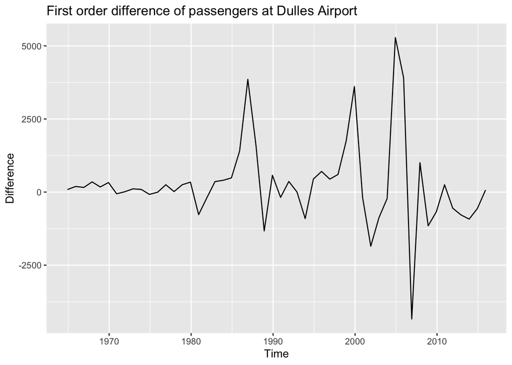

```r
autoplot(Diff_1, xlab='Time', ylab = "Difference", main = "First order difference of passengers at Dulles Airport")
```

### -Growth Rates Time Series Plot for the Growth Rate for the Dulles Passenger Series

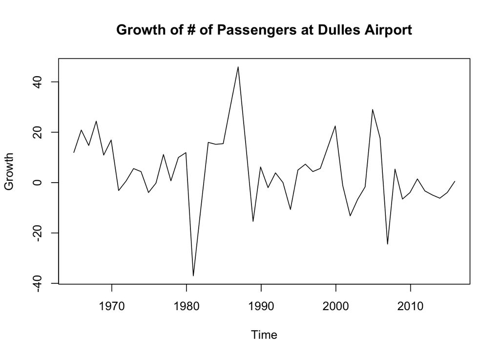

```r
Growth_1 <- 100* Diff_1 / Dulles.plot
plot(Growth_1, xlab='Time',ylab = "Growth", main= "Growth of # of Passengers at Dulles Airport")
```

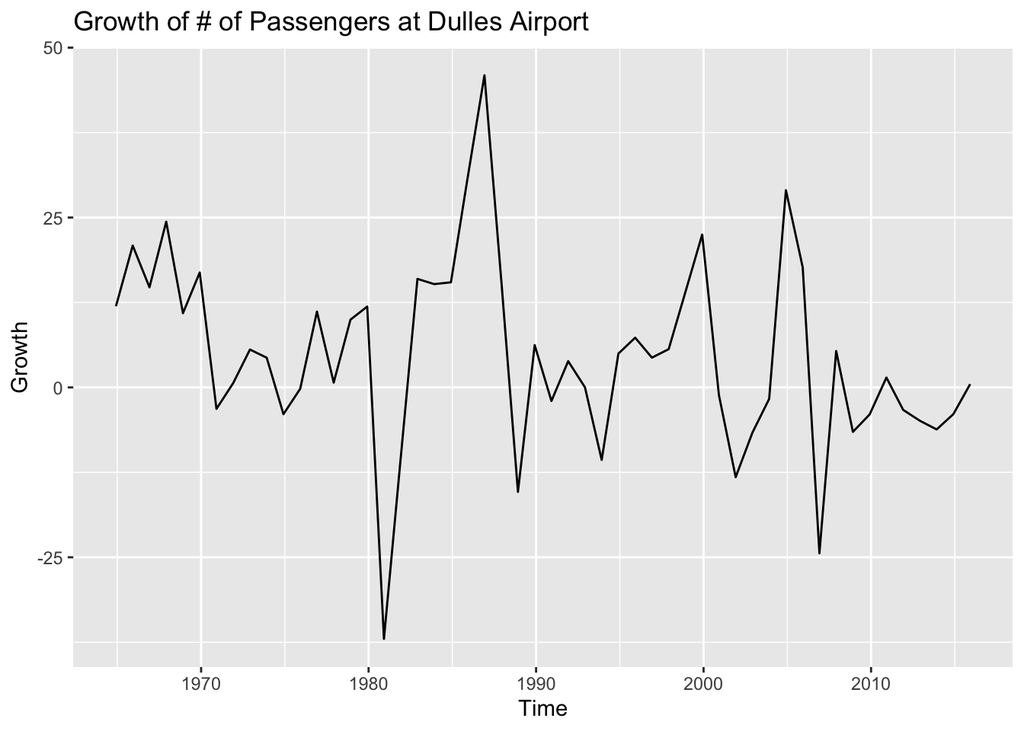

```r
autoplot(Growth_1, xlab='Time',ylab = "Growth", main= "Growth of # of Passengers at Dulles Airport")
```

### -Logarithm

#### Log Transform

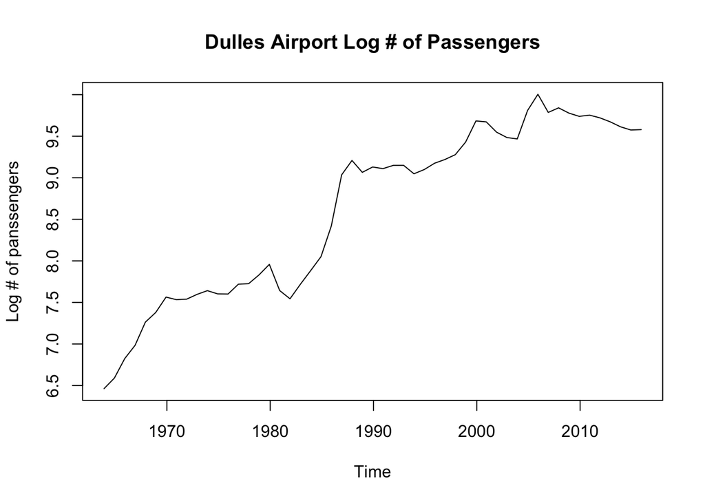

```r
Log_Dulles <- log(Dulles.plot)
plot(Log_Dulles, xlab='Time', ylab = "Log # of panssengers",main = "Dulles Airport Log # of Passengers")
```

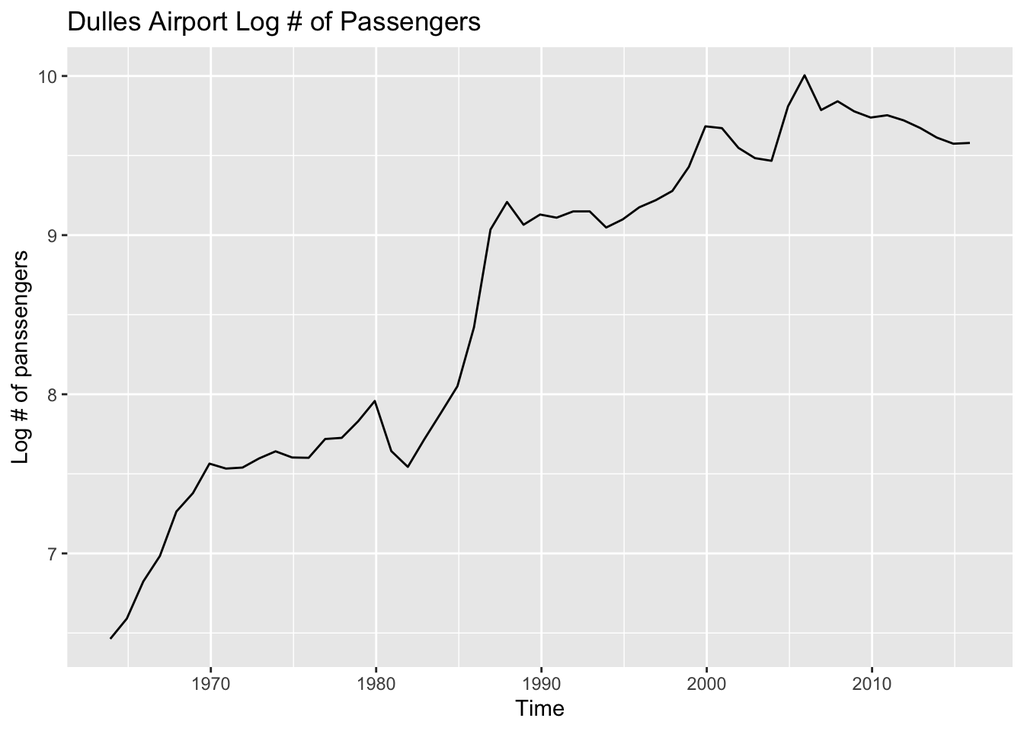

```r
autoplot(Log_Dulles, xlab='Time', ylab = "Log # of panssengers",main = "Dulles Airport Log # of Passengers")
```

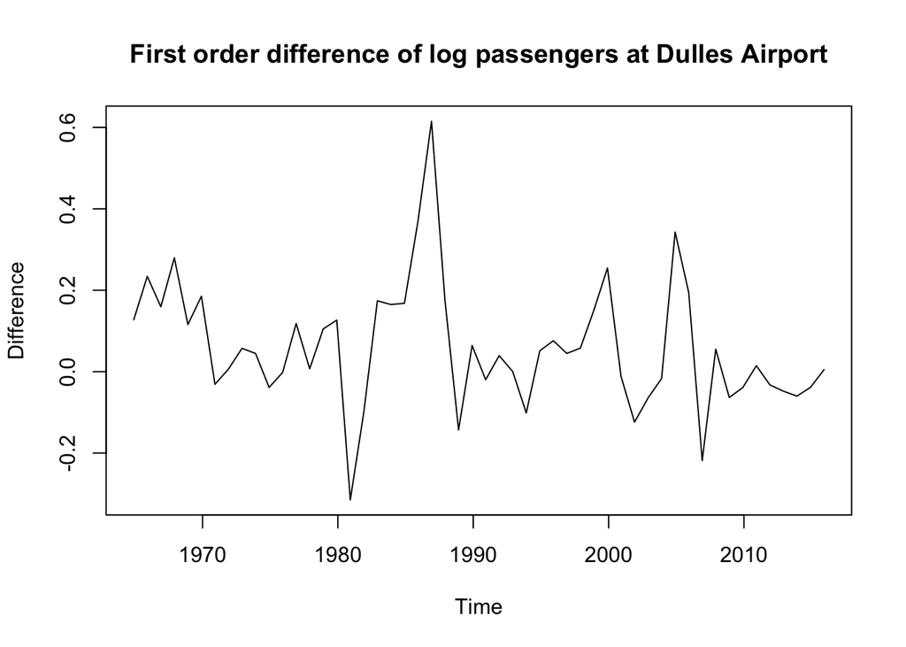

```r
log_diff_1 <- diff(Log_Dulles, differences = 1)
plot(log_diff_1, xlab='Time', ylab = "Difference", main = "First order difference of log passengers at Dulles Airport")
```

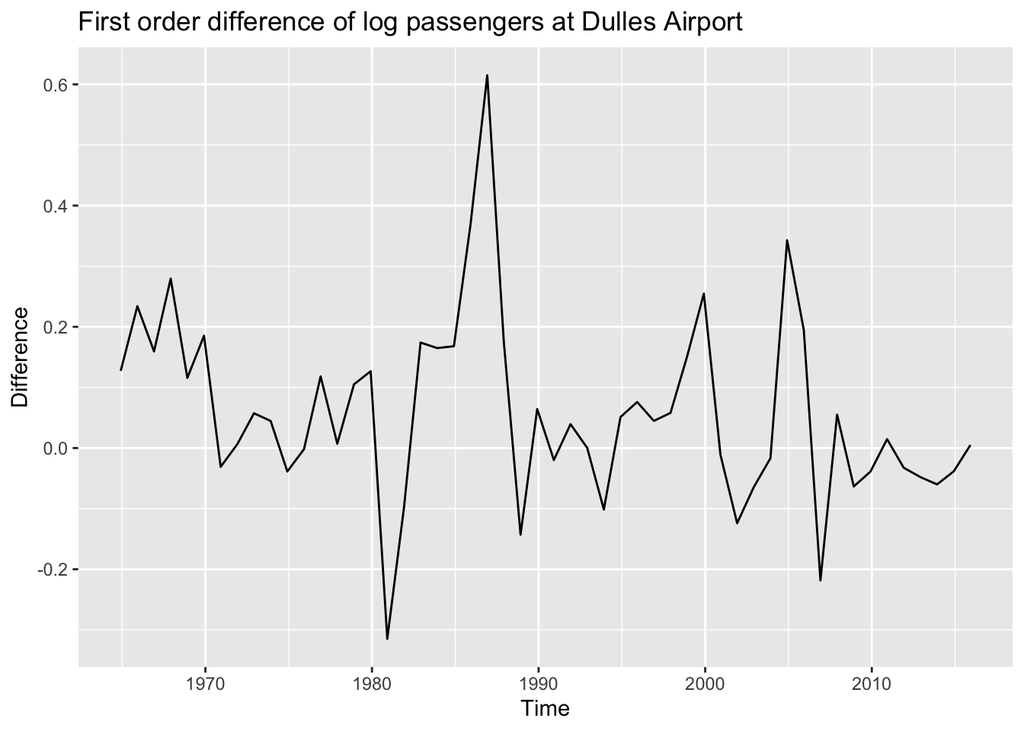

```r
autoplot(log_diff_1, xlab='Time', ylab = "Difference", main = "First order difference of log passengers at Dulles Airport")
```

**Do the log_diff plot looks like the growth plot?**

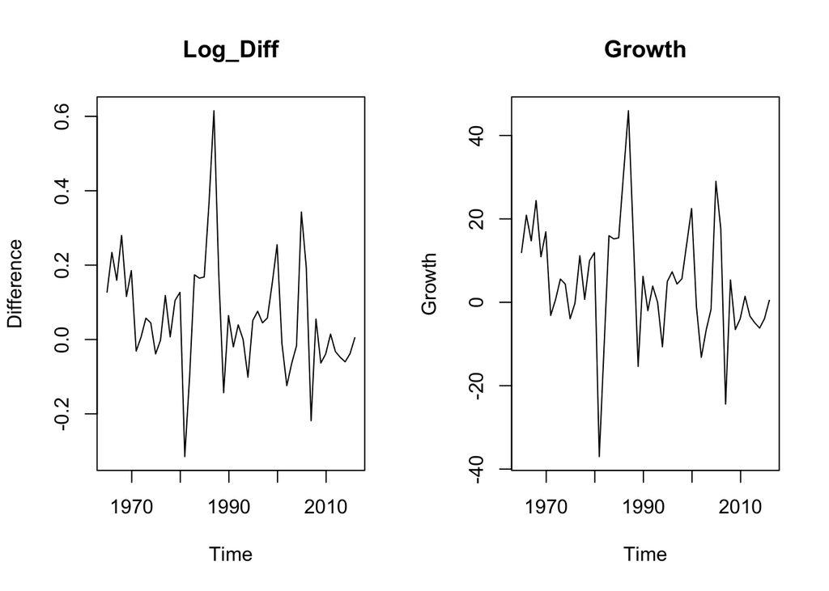

```r
layout(t(1:2))
plot(log_diff_1, xlab='Time', ylab = "Difference", main = "Log_Diff")
plot(Growth_1, xlab='Time',ylab = "Growth", main= "Growth")
```

```r
layout(1)
```

### How to Evaluate Forecasting Accuracy

This process is known as rolling origin forecasting. The one-step-ahead forecast error at time t+i may be denoted by

$$e_{t+i}=Y_{t+i}−F_{t+i}$$

#### Example:

```r
DC_weather <- read.csv("dc_weather.csv", header = T)
colnames(DC_weather) <- c("Date", "Forecast", "Actual")
DC_weather$Date <- as.Date(DC_weather$Date, "%m/%d/%y")
str(DC_weather)
```

```
## 'data.frame':    35 obs. of  3 variables:
##  $ Date    : Date, format: "2021-06-01" "2021-06-02" ...
##  $ Forecast: int  82 82 83 86 85 85 74 80 81 94 ...
##  $ Actual  : int  NA 82 81 82 85 87 87 74 82 82 ...
```

```r
#summary(DC_weather)
```

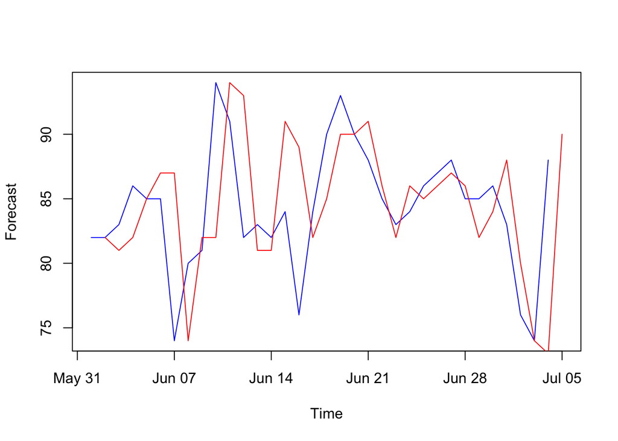

```r
# Draw time series
plot(x = DC_weather$Date, y = DC_weather$Forecast, xlab='Time', ylab="Forecast", type="l", col="blue")
lines(x = DC_weather$Date, y = DC_weather$Actual, xlab='Time', ylab="Actual", col="red")
```

```r
# Calculate the forecast error
Actual1 <- DC_weather$Actual[c(-1)]
Forecast1 <- DC_weather$Forecast[-dim(DC_weather)[1]]
error <- Actual1 - Forecast1
```

**Mean Error**

```r
# Mean error
ME <- mean(error)
ME
```

```
## [1] 0.3823529
```

**Mean Percentage Error**

```r
# Mean Percentage Error
MPE <- 100 * mean(error/DC_weather$Actual[-1])
MPE
```

```
## [1] 0.3828892
```

**Mean absolute error**

```r
MAE <- mean(abs(error))
MAE
```

```
## [1] 1.911765
```

**Mean absolute percentage error**

```r
# Mean absolute percentage error
MAPE <- 100 * mean(abs(error/DC_weather$Actual[-1]))
MAPE
```

```
## [1] 2.244587
```

**Mean square error**

```r
MSE <- mean(error^2)
MSE
```

```
## [1] 6.970588
```

**Root mean square error**

```r
RMSE <- sqrt(MSE)
RMSE
```

```
## [1] 2.640187
```

**Relative absolute error**

```r
Diff_1 <- diff(DC_weather$Actual,lag = 1,differences = 1)
RelMAE <- sum(abs(error[-1])) / sum(abs(Diff_1[-1]))
RelMAE
```

```
## [1] 0.4642857
```

**Theil’s U**

```r
Theil_U <- sqrt(sum(error[-1]^2)) / sqrt(sum(Diff_1[-1]^2))
Theil_U
```

```
## [1] 0.4422042
```

## Prediction Interval

### Normal Prediction Intervals

We can use the method of Normal Distribution to get a prediction confidence interval. We can get the lower and upper limits through the way of:

$$\begin{aligned}
\text{Lower} &= F_{t+1} - Z * \text{RMSE}\\
\text{Upper} &= F_{t+1} + Z * \text{RMSE}\\
\end{aligned}$$
How to get the corresponding Z-score to a given $100*(1-\alpha)$ level of confidence?

You can use the function qnorm() to get the Z-score.

$$\text{qnorm}(1-\frac{\alpha}{2})$$

```r
# For example, you want to get the 95% confidence level. Then here the aplha = 0.05. So (1 - alpha/2) = 0.975
qnorm(0.975)
```

```
## [1] 1.959964
```

```r
RMSE
```

```
## [1] 2.640187
```

```r
DC_weather[6,]
```

```
##         Date Forecast Actual
## 6 2021-06-06       85     87
```

```r
prediction_lower <- DC_weather$Forecast[6] - 1.96 * RMSE
prediction_upper <- DC_weather$Forecast[6] + 1.96 * RMSE
prediction_lower
```

```
## [1] 79.82523
```

```r
prediction_upper
```

```
## [1] 90.17477
```

### Empirical Prediction Intervals

```r
length(error)
```

```
## [1] 34
```

```r
0.025 * 35
```

```
## [1] 0.875
```

```r
0.975 * 35
```

```
## [1] 34.125
```

```r
# So let's take the 1st error term and the 34th error term
sort(error)[1]
```

```
## [1] -3
```

```r
sort(error)[34]
```

```
## [1] 9
```

```r
# therefore the lower and upper limits are:
DC_weather$Forecast[6] + sort(error)[1]
```

```
## [1] 82
```

```r
DC_weather$Forecast[6] + sort(error)[34]
```

```
## [1] 94
```